# Introduction to R workshop notes

# Welcome

## Materials and setup

**NOTE: skip this section if you are not running R locally** (e.g., if you are running R in your browser using a remote Jupyter server)

You should have R installed –if not:

- Download and install R from http://cran.r-project.org
- Download and install RStudio from https://www.rstudio.com/products/rstudio/download/#download

Start RStudio and open a new R script: - On Windows click the start button and search for rstudio. On Mac RStudio will be in your applications folder. - In Rstudio go to `File -> New File -> R Script`

## What is R?

R is a *programming language designed for statistical computing*. Notable characteristics include:

- Vast capabilities, wide range of statistical and graphical techniques
- Very popular in academia, growing popularity in business: http://r4stats.com/articles/popularity/
- Written primarily by statisticians
- FREE (no monetary cost and open source)
- Excellent community support: mailing list, blogs, tutorials
- Easy to extend by writing new functions

Whatever you’re trying to do, you’re probably not the first to try doing it R. Chances are good that someone has already written a package for that.

# Graphical User Interfaces (GUIs)

For this workshop I encourage you to use RStudio; it is a good R-specific IDE that mostly just works.

## Launch RStudio (skip if not using Rstudio)

**Note: skip this section if you are not using Rstudio (e.g., if you are running these examples in a Jupyter notebook).**

The window in the upper-left is your R script. This is where you will write instructions for R to carry out.

The window in the lower-left is the R console. This is where results will be displayed.

## Exercise 0

The purpose of this exercise is to give you an opportunity to explore the interface provided by RStudio (or whichever GUI you’ve decided to use). You may not know how to do these things; that’s fine! This is an opportunity to figure it out.

Also keep in mind that we are living in a golden age of tab completion. If you don’t know the name of an R function, try guessing the first two or three letters and pressing TAB. If you guessed correctly the function you are looking for should appear in a pop up!

1. Try to get R to add 2 plus 2.

```r
##
```

2. Try to calculate the square root of 10.

```r
##
```

3. R includes extensive documentation, including a file named “An introduction to R”. Try to find this help file.

## Exercise 0 solution

```r
## 1. 2 plus 2
2 + 2
```

```
## [1] 4
```

```r
## or
sum(2, 2)
```

```
## [1] 4
```

```r
## 2. square root of 10:
sqrt(10)
```

```
## [1] 3.162278
```

```r
## or
10^(1/2)
```

```
## [1] 3.162278
```

```r
## 3. Find "An Introduction to R".

## Go to the main help page by running 'help.start() or using the GUI
## menu, find and click on the link to "An Introduction to R".
```

# R basics

## Function calls

The general form for calling R functions is

```r
## FunctionName(arg.1 = value.1, arg.2 = value.2, ..., arg.n - value.n)
```

Arguments can be matched by name; unnamed arguments will be matched by position.

## Assignment

Values can be assigned names and used in subsequent operations

- The `<-` operator (less than followed by a dash) is used to save values
- The name on the left gets the value on the right.

```r
sqrt(10) ## calculate square root of 10; result is not stored anywhere
```

```
## [1] 3.162278
```

```r
x <- sqrt(10) # assign result to a variable named x
```

## Asking R for help

You can ask R for help using the `help` function, or the `?` shortcut.

```r
help(help)
```

```
## starting httpd help server ... done
```

The `help` function can be used to look up the documentation for a function, or to look up the documentation to a package. We can learn how to use the `stats` package by reading its documentation like this:

```r
help(package = "stats")
```

# Example project: baby names!

## General goals

I would like to know what the most popular baby names are. In the course of answering this question we will learn to call R functions, install and load packages, assign values to names, read and write data, and more.

## Data sets

The examples in this workshop use the baby names data provided by the governments of the United States and the United Kingdom. A cleaned and merged version of these data is available at `http://tutorials.iq.harvard.edu/R/Rintro/dataSets/babyNames.csv`.

# Getting data into R

R has data reading functionality built-in – see e.g., `help(read.table)`. However, faster and more robust tools are available, and so to make things easier on ourselves we will use a *contributed package* called `readr` instead. This requires that we learn a little bit about packages in R.

## Installing and using R packages

A large number of contributed packages are available. If you are looking for a package for a specific task, https://cran.r-project.org/web/views/ and https://r-pkg.org are good places to start.

You can install a package in R using the `install.packages()` function. Once a package is installed you may use the `library` function to attach it so that it can be used.

```r
## install.packages("readr")
library(readr)
```

## Readers for common file types

In order to read data from a file, you have to know what kind of file it is. The table below lists functions that can import data from common plain-text formats.

| Data Type | Function |
| --- | --- |
| comma separated | `read_csv()` |
| tab separated | `read_delim()` |
| other delimited formats | `read_table()` |
| fixed width | `read_fwf()` |

**Note** You may be confused by the existence of similar functions, e.g., `read.csv` and `read.delim`. These are legacy functions that tend to be slower and less robust than the `readr` functions. One way to tell them apart is that the faster more robust versions use underscores in their names (e.g., `read_csv`) while the older functions us dots (e.g., `read.csv`). My advice is to use the more robust newer versions, i.e., the ones with underscores.

## Exercise 2

The purpose of this exercise is to practice reading data into R.

1. Open the help page for the `read_csv` function. How can you limit the number of rows to be read in?

```r
##
```

2. Read just the first 10 rows of “`"http://tutorials.iq.harvard.edu/R/Rintro/dataSets/babyNames.csv`”.

```r
##
```

3. Once you have successfully read in the first 10 rows, read the whole file, assigning the result to the name `baby.names`.

```r
##
```

## Exercise 2 solution

```r
## read ?read_csv

## limit rows with nrows argument
library(readr)
babyNames <- read_csv("C:/Users/HarrieJonkman/OneDrive - Verwey-Jonker Instituut/Rcursus/1.Introduceren/babyNames.csv",
                      n_max = 10 )
#read_csv("http://tutorials.iq.harvard.edu/R/Rintro/dataSets/babyNames.csv",
#        n_max = 10)
## read all the data
baby.names <- read_csv("C:/Users/HarrieJonkman/OneDrive - Verwey-Jonker Instituut/Rcursus/1.Introduceren/babyNames.csv")
```

# Data Manipulation

## data.frame objects

Usually data read into R will be stored as a **data.frame**

- A data.frame is a list of vectors of equal length
  - Each vector in the list forms a column
  - Each column can be a differnt type of vector
  - Typically columns are variables and the rows are observations

A data.frame has two dimensions corresponding the number of rows and the number of columns (in that order)

## Tools for manipulating data.frame objects

R has decent data manipulation tools built-in – see e.g., `help(Extract)`. However, these tools are powerful and complex and often overwhelm beginners. To make things easier on ourselves we will use a *contributed package* called `dplyr` instead.

```r
## install.packages("dplyr")
library(dplyr)
```

## Checking imported data

It is always a good idea to examine the imported data set–usually we want the results to be a `data.frame`

```r
class(baby.names) # check to see that it os a data.frame
```

```
## [1] "tbl_df"     "tbl"        "data.frame"
```

We can get more information about R objects using the `glimpse` function.

```r
glimpse(baby.names) # structure
```

```
## Observations: 197,106
## Variables: 8
## $ Year      <int> 1996, 1996, 1996, 1996, 1996, 1996, 1996, 1996, 1996...
## $ Sex       <chr> "Female", "Female", "Female", "Female", "Female", "F...
## $ Name      <chr> "aaliyah", "aarin", "aaron", "abagail", "abbey", "ab...
## $ Count     <int> 802, 5, 26, 87, 510, 5, 311, 235, 17, 1402, 8, 5, 5,...
## $ Thousands <dbl> 0.802, 0.005, 0.026, 0.087, 0.510, 0.005, 0.311, 0.2...
## $ Decade    <chr> "1990's", "1990's", "1990's", "1990's", "1990's", "1...
## $ Popular   <lgl> FALSE, FALSE, FALSE, FALSE, FALSE, FALSE, FALSE, FAL...
## $ max_count <int> 25150, 25150, 25150, 25150, 25150, 25150, 25150, 251...
```

```r
View(baby.names) # visually inspect
```

## Filter data.frame rows

You can extract subsets of data.frames using `filter` to select rows meeting some condition.

```r
## rows where Name == "jill"
filter(baby.names, Name == "jill")
```

```
## # A tibble: 19 x 8
##     Year Sex    Name  Count Thousands Decade Popular max_count
##    <int> <chr>  <chr> <int>     <dbl> <chr>  <lgl>       <int>
##  1  1996 Female jill    306     0.306 1990's FALSE       25150
##  2  1997 Female jill    254     0.254 1990's FALSE       25731
##  3  1998 Female jill    206     0.206 1990's FALSE       26179
##  4  1999 Female jill    169     0.169 1990's FALSE       26537
##  5  2000 Female jill    168     0.168 2000's FALSE       25953
##  6  2001 Female jill    130     0.13  2000's FALSE       25052
##  7  2002 Female jill     85     0.085 2000's FALSE       24459
##  8  2003 Female jill     83     0.083 2000's FALSE       25685
##  9  2004 Female jill     53     0.053 2000's FALSE       25028
## 10  2005 Female jill     61     0.061 2000's FALSE       23930
## 11  2006 Female jill    108     0.108 2000's FALSE       21393
## 12  2007 Female jill     42     0.042 2000's FALSE       19350
## 13  2008 Female jill     25     0.025 2000's FALSE       18803
## 14  2009 Female jill     34     0.034 2000's FALSE       22283
## 15  2010 Female jill     31     0.031 2010's FALSE       22890
## 16  2011 Female jill      5     0.005 2010's FALSE       21824
## 17  2013 Female jill     13     0.013 2010's FALSE       21171
## 18  2014 Female jill     18     0.018 2010's FALSE       20886
## 19  2015 Female jill      7     0.007 2010's FALSE       20355
```

```r
## rows where Year is 1996 and Name is either "jack" or "jill"
filter(baby.names, Year == 1996 & Name %in% c("jack", "jill"))
```

```
## # A tibble: 2 x 8
##    Year Sex    Name  Count Thousands Decade Popular max_count
##   <int> <chr>  <chr> <int>     <dbl> <chr>  <lgl>       <int>
## 1  1996 Female jill    306     0.306 1990's FALSE       25150
## 2  1996 Male   jack   4240     4.24  1990's FALSE       38322
```

In the previous example we used `==` to filter rows. Other relational and logical operators are listed below.

| Operator | Meaning |
| --- | --- |
| `==` | equal to |
| `!=` | not equal to |
| `>` | greater than |
| `>=` | greater than or equal to |
| `<` | less than |
| `<=` | less than or equal to |
| `%in%` | contained in |

These operators may be combined with `&` (and) or `|` (or).

## Exercise 2: Data Extraction

Read in the “babyNames.csv” file if you have not already done so, assigning the result to `baby.names`. The file is located at “http://tutorials.iq.harvard.edu/R/Rintro/dataSets/babyNames.csv”

1. Extract data for the name “ashley”.

```r
##
```

2. Restrict the previous extraction to include only years between 2000 and 2004.

```r
##
```

## Exercise 2 solution

```r
## 1. Extract data for the name "ashley".
filter(baby.names, Name == "ashley")
```

```
## # A tibble: 39 x 8
##     Year Sex    Name   Count Thousands Decade Popular max_count
##    <int> <chr>  <chr>  <int>     <dbl> <chr>  <lgl>       <int>
##  1  1996 Female ashley 23676    23.7   1990's FALSE       25150
##  2  1996 Male   ashley    64     0.064 1990's FALSE       38322
##  3  1997 Female ashley 20895    20.9   1990's FALSE       25731
##  4  1997 Male   ashley    63     0.063 1990's FALSE       37505
##  5  1998 Female ashley 19871    19.9   1990's FALSE       26179
##  6  1998 Male   ashley    27     0.027 1990's FALSE       36569
##  7  1999 Female ashley 18132    18.1   1990's FALSE       26537
##  8  1999 Male   ashley    28     0.028 1990's FALSE       35306
##  9  2000 Female ashley 17997    18.0   2000's FALSE       25953
## 10  2000 Male   ashley    44     0.044 2000's FALSE       34418
## # ... with 29 more rows
```

```r
## 2.  Restrict the previous extraction to include only years between 2000 and 2004.
filter(baby.names,
       Year >= 2000 &
       Year <= 2004 &
       Name == "ashley")
```

```
## # A tibble: 10 x 8
##     Year Sex    Name   Count Thousands Decade Popular max_count
##    <int> <chr>  <chr>  <int>     <dbl> <chr>  <lgl>       <int>
##  1  2000 Female ashley 17997    18.0   2000's FALSE       25953
##  2  2000 Male   ashley    44     0.044 2000's FALSE       34418
##  3  2001 Female ashley 16524    16.5   2000's FALSE       25052
##  4  2001 Male   ashley    33     0.033 2000's FALSE       32487
##  5  2002 Female ashley 15339    15.3   2000's FALSE       24459
##  6  2002 Male   ashley    18     0.018 2000's FALSE       30509
##  7  2003 Female ashley 14512    14.5   2000's FALSE       25685
##  8  2003 Male   ashley    31     0.031 2000's FALSE       29573
##  9  2004 Female ashley 14370    14.4   2000's FALSE       25028
## 10  2004 Male   ashley    57     0.057 2000's FALSE       27842
```

## Adding, removing, and modifying data.frame columns

You can modify data.frames using `mutate` function. It works like this:

```r
baby.names <- mutate(baby.names, Thousands = Count/1000)
baby.names
```

```
## # A tibble: 197,106 x 8
##     Year Sex    Name     Count Thousands Decade Popular max_count
##    <int> <chr>  <chr>    <int>     <dbl> <chr>  <lgl>       <int>
##  1  1996 Female aaliyah    802     0.802 1990's FALSE       25150
##  2  1996 Female aarin        5     0.005 1990's FALSE       25150
##  3  1996 Female aaron       26     0.026 1990's FALSE       25150
##  4  1996 Female abagail     87     0.087 1990's FALSE       25150
##  5  1996 Female abbey      510     0.51  1990's FALSE       25150
##  6  1996 Female abbi         5     0.005 1990's FALSE       25150
##  7  1996 Female abbie      311     0.311 1990's FALSE       25150
##  8  1996 Female abbigail   235     0.235 1990's FALSE       25150
##  9  1996 Female abbigale    17     0.017 1990's FALSE       25150
## 10  1996 Female abby      1402     1.40  1990's FALSE       25150
## # ... with 197,096 more rows
```

Often one needs to replace values conditionally, as in the following example:

```r
baby.names <- mutate(
    baby.names,
    Decade = case_when(Year < 2000                ~ "1990's",
                       Year >= 2000 & Year < 2010 ~ "2000's",
                       Year < 2020                ~ "2010's",
                       TRUE                       ~ as.character(Year)))

head(baby.names)
```

```
## # A tibble: 6 x 8
##    Year Sex    Name    Count Thousands Decade Popular max_count
##   <int> <chr>  <chr>   <int>     <dbl> <chr>  <lgl>       <int>
## 1  1996 Female aaliyah   802     0.802 1990's FALSE       25150
## 2  1996 Female aarin       5     0.005 1990's FALSE       25150
## 3  1996 Female aaron      26     0.026 1990's FALSE       25150
## 4  1996 Female abagail    87     0.087 1990's FALSE       25150
## 5  1996 Female abbey     510     0.51  1990's FALSE       25150
## 6  1996 Female abbi        5     0.005 1990's FALSE       25150
```

```r
tail(baby.names)
```

```
## # A tibble: 6 x 8
##    Year Sex   Name    Count Thousands Decade Popular max_count
##   <int> <chr> <chr>   <int>     <dbl> <chr>  <lgl>       <int>
## 1  2015 Male  william    19     0.019 2010's FALSE       19485
## 2  2015 Male  wyatt      29     0.029 2010's FALSE       19485
## 3  2015 Male  xavier     11     0.011 2010's FALSE       19485
## 4  2015 Male  zander      6     0.006 2010's FALSE       19485
## 5  2015 Male  zane        6     0.006 2010's FALSE       19485
## 6  2015 Male  zayden      6     0.006 2010's FALSE       19485
```

## Exercise 3: Data manipulation

Read in the “babyNames.csv” file if you have not already done so, assigning the result to `baby.names`. The file is located at “http://tutorials.iq.harvard.edu/R/Rintro/dataSets/babyNames.csv”

1. Ifyou look at `unique(baby.names$Sex)` you’ll notice that some records indicate Male with `"M"`, while other records use `"Male"`. Correct this by replacing `"M"` with `"Male"`.

```r
##
```

2. Create a column named “Popular” containing a 1 in rows where Count is greater than 30000 and a 0 otherwise

```r
##
```

3. Filter the baby names data to display only the popular names.

```r
##
```

## Exercise 3 solution

```r
# 1
baby.names <- mutate(baby.names,
                     Sex = case_when(Sex == "M" ~ "Male",
                                     TRUE ~ Sex))

# 2
baby.names <- mutate(baby.names,
                     Popular = case_when(Count < 30000 ~ FALSE,
                                         Count >= 30000 ~ TRUE))

# 3
filter(baby.names, Popular)
```

```
## # A tibble: 17 x 8
##     Year Sex   Name        Count Thousands Decade Popular max_count
##    <int> <chr> <chr>       <int>     <dbl> <chr>  <lgl>       <int>
##  1  1996 Male  christopher 30870      30.9 1990's TRUE        38322
##  2  1996 Male  jacob       31864      31.9 1990's TRUE        38322
##  3  1996 Male  matthew     32031      32.0 1990's TRUE        38322
##  4  1996 Male  michael     38322      38.3 1990's TRUE        38322
##  5  1997 Male  jacob       34090      34.1 1990's TRUE        37505
##  6  1997 Male  matthew     31480      31.5 1990's TRUE        37505
##  7  1997 Male  michael     37505      37.5 1990's TRUE        37505
##  8  1998 Male  jacob       35958      36.0 1990's TRUE        36569
##  9  1998 Male  matthew     31091      31.1 1990's TRUE        36569
## 10  1998 Male  michael     36569      36.6 1990's TRUE        36569
## 11  1999 Male  jacob       35306      35.3 1990's TRUE        35306
## 12  1999 Male  matthew     30388      30.4 1990's TRUE        35306
## 13  1999 Male  michael     33854      33.9 1990's TRUE        35306
## 14  2000 Male  jacob       34418      34.4 2000's TRUE        34418
## 15  2000 Male  michael     31992      32.0 2000's TRUE        34418
## 16  2001 Male  jacob       32487      32.5 2000's TRUE        32487
## 17  2002 Male  jacob       30509      30.5 2000's TRUE        30509
```

## Grouping and Aggregation

So far we’ve seen than “Jacob”, “Matthew”, and “Michael” tend to be popular names. That isn’t very satisfying, because it leaves us wanting to know which girls names are popular, and perhaps how popularity has changed over time. To answer these questions we need to operate on groups within the data rather than on the whole data structure at once. The `dplyr` package makes this easy to do using the `group_by` function.

```r
baby.names <- mutate(group_by(baby.names, Year, Sex),
                     max_count = max(Count))
head(baby.names)
```

```
## # A tibble: 6 x 8
## # Groups:   Year, Sex [1]
##    Year Sex    Name    Count Thousands Decade Popular max_count
##   <int> <chr>  <chr>   <int>     <dbl> <chr>  <lgl>       <dbl>
## 1  1996 Female aaliyah   802     0.802 1990's FALSE       25150
## 2  1996 Female aarin       5     0.005 1990's FALSE       25150
## 3  1996 Female aaron      26     0.026 1990's FALSE       25150
## 4  1996 Female abagail    87     0.087 1990's FALSE       25150
## 5  1996 Female abbey     510     0.51  1990's FALSE       25150
## 6  1996 Female abbi        5     0.005 1990's FALSE       25150
```

```r
tail(baby.names)
```

```
## # A tibble: 6 x 8
## # Groups:   Year, Sex [1]
##    Year Sex   Name    Count Thousands Decade Popular max_count
##   <int> <chr> <chr>   <int>     <dbl> <chr>  <lgl>       <dbl>
## 1  2015 Male  william    19     0.019 2010's FALSE       19485
## 2  2015 Male  wyatt      29     0.029 2010's FALSE       19485
## 3  2015 Male  xavier     11     0.011 2010's FALSE       19485
## 4  2015 Male  zander      6     0.006 2010's FALSE       19485
## 5  2015 Male  zane        6     0.006 2010's FALSE       19485
## 6  2015 Male  zayden      6     0.006 2010's FALSE       19485
```

```r
filter(baby.names,
       Count == max_count)
```

```
## # A tibble: 40 x 8
## # Groups:   Year, Sex [40]
##     Year Sex    Name    Count Thousands Decade Popular max_count
##    <int> <chr>  <chr>   <int>     <dbl> <chr>  <lgl>       <dbl>
##  1  1996 Female emily   25150      25.2 1990's FALSE       25150
##  2  1996 Male   michael 38322      38.3 1990's TRUE        38322
##  3  1997 Female emily   25731      25.7 1990's FALSE       25731
##  4  1997 Male   michael 37505      37.5 1990's TRUE        37505
##  5  1998 Female emily   26179      26.2 1990's FALSE       26179
##  6  1998 Male   michael 36569      36.6 1990's TRUE        36569
##  7  1999 Female emily   26537      26.5 1990's FALSE       26537
##  8  1999 Male   jacob   35306      35.3 1990's TRUE        35306
##  9  2000 Female emily   25953      26.0 2000's FALSE       25953
## 10  2000 Male   jacob   34418      34.4 2000's TRUE        34418
## # ... with 30 more rows
```

Note that the data remains grouped until you change the groups by running `group_by` again or remove grouping information with `ungroup`.

Grouping can be useful when modifying a data.frame with `mutate` or extracting subsets with `filter`, but it really shines when combined with `summarize`. For example, suppose that we want the most popular girl and boy names for each decade. In this case we need to summarize the by summing the `Count` column for each `Sex X Decade` group.

```r
bn.by.decade <- summarize(group_by(baby.names, Decade, Sex, Name),
                          Count = sum(Count),
                          Thousands = sum(Thousands))

filter(group_by(bn.by.decade, Decade, Sex),
                     Count == max(Count))
```

```
## # A tibble: 6 x 5
## # Groups:   Decade, Sex [6]
##   Decade Sex    Name     Count Thousands
##   <chr>  <chr>  <chr>    <int>     <dbl>
## 1 1990's Female emily   103597      104.
## 2 1990's Male   michael 146430      146.
## 3 2000's Female emily   223612      224.
## 4 2000's Male   jacob   273690      274.
## 5 2010's Female sophia  121787      122.
## 6 2010's Male   jacob   112227      112.
```

In the previous example we used `sum` and `max`, two examples of basic statistics functions in R. Other basic statistics functions include: - `mean` - `median` - `sd` - `var` - `min` - `quantile` - `length`

## Exporting Data

Now that we have made some changes to our data set, we might want to save those changes to a file.

```r
# write data to a .csv file
write_csv(baby.names, "babyNames.csv")

# write data to an R file
write_rds(baby.names, "babyNames.rds")
```

## Saving and loading R workspaces

In addition to importing individual datasets, R can save and load entire workspaces

```r
ls() # list objects in our workspace
```

```
## [1] "baby.names"   "babyNames"    "bn.by.decade" "x"
```

```r
save.image(file="myWorkspace.RData") # save workspace
rm(list=ls()) # remove all objects from our workspace
ls() # list stored objects to make sure they are deleted
```

```
## character(0)
```

```r
## Load the "myWorkspace.RData" file and check that it is restored
load("myWorkspace.RData") # load myWorkspace.RData
ls() # list objects
```

```
## [1] "baby.names"   "babyNames"    "bn.by.decade" "x"
```

## Exercise 4

1. Calculate the total number of children born.
2. Filter the data to extract data from 2004 and calculate the total number of children born in that year.

```r
##
```

3. Calculate the number of boys and girls born each year. Assign the result to the name `births.by.year`.

```r
##
```

## Exercise 4 solution

```r
## 1.  Calculate the total number of children born.
baby.names <- ungroup(baby.names)
summarize(baby.names, Total = sum(Count))
```

```
## # A tibble: 1 x 1
##      Total
##      <int>
## 1 64519299
```

```r
## 2.  Filter the data to extract data from 2004 and calculate the total
##     number of children born in that year.
summarize(filter(baby.names, Year == 2004), Total = sum(Count))
```

```
## # A tibble: 1 x 1
##     Total
##     <int>
## 1 3294392
```

```r
## 3.  Calculate the number of boys and girls born each year. Assign the result
##     to the name `births.by.year`.
births.by.year <- summarize(group_by(baby.names, Year, Sex),
                            Count = sum(Count))
births.by.year
```

```
## # A tibble: 40 x 3
## # Groups:   Year [?]
##     Year Sex      Count
##    <int> <chr>    <int>
##  1  1996 Female 1497121
##  2  1996 Male   1728057
##  3  1997 Female 1478802
##  4  1997 Male   1714552
##  5  1998 Female 1496488
##  6  1998 Male   1733194
##  7  1999 Female 1497247
##  8  1999 Male   1736147
##  9  2000 Female 1527247
## 10  2000 Male   1769871
## # ... with 30 more rows
```

# Basic graphs

R has decent plotting tools built-in – see e.g., `help(plot)`. However, To make things easier on ourselves we will use a *contributed package* called `ggplot2` instead.

```r
## install.packages("ggplot2")
library(ggplot2)
```

First, we’ll plot the number of boys and girls born each year.

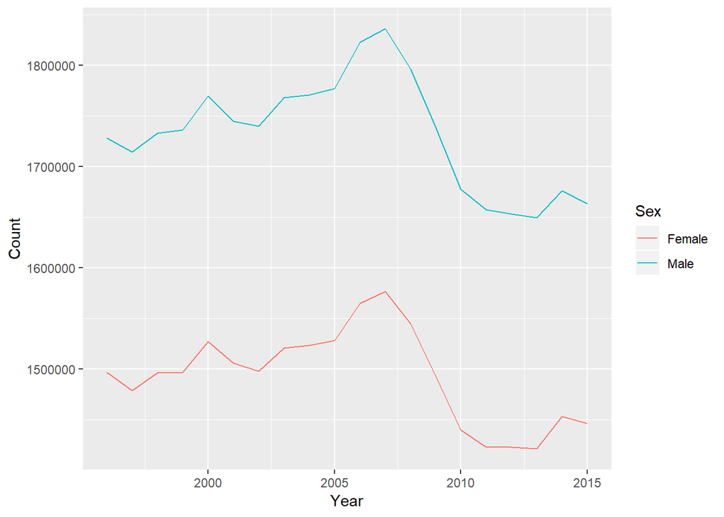

```r
qplot(Year, Count, color = Sex,
     geom = "line",
     data = births.by.year)
```

Next, we’ll filter out the most popular girls names and plot their popularity over time.

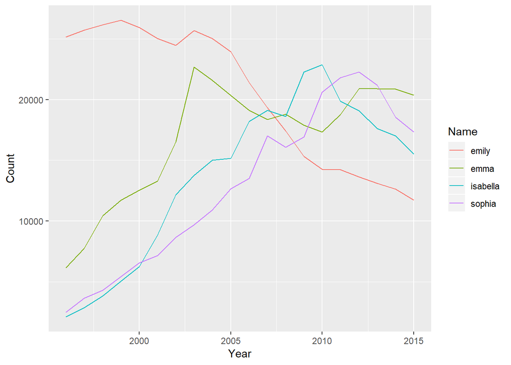

```r
popular.girls <- filter(group_by(baby.names, Year, Sex),
                       Sex == "Female" & Count == max(Count))

qplot(Year, Count, color = Name,
     geom = "line",
     data = filter(baby.names,
                   Sex == "Female" & Name %in% popular.girls$Name))
```

## Exercise 5

1. Add a new coloumn to the baby.names data equal to the proportion of boys and girls born each year with each name. That is, calculate Proportion = Count/sum(Count) for each Year X Sex group.

```r
##
```

2. Filter the baby.names data, retaining only the most popular girl and boy names for each year.

```r
##
```

3. Plot proportion over time to see changes in the proportion of parents choosing the most popular name of the year.

```r
##
```

## Exercise 5 solution

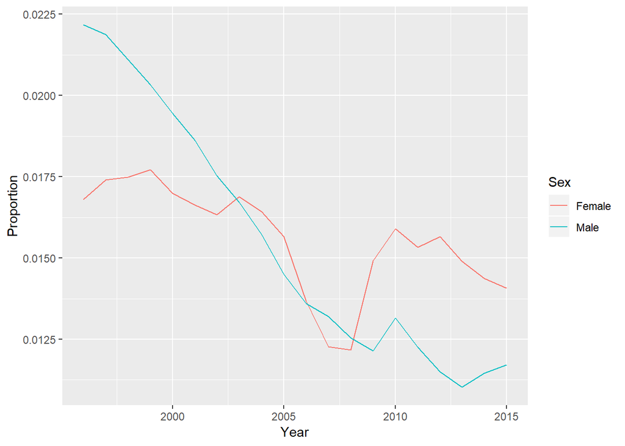

```r
## 1. Add a new coloumn to the baby.names data equal to the proportion
## of boys and girls born each year with each name. That is, calculate
## Proportion = Count/sum(Count) for each Year X Sex group.

baby.names <- mutate(group_by(baby.names, Year, Sex),
                     Proportion = Count / sum(Count))

## 2. Filter the baby.names data, retaining only the most popular girl
## and boy names for each year.

bn.top.prop <- filter(group_by(baby.names, Year, Sex),
                      Proportion == max(Proportion))

## 3. Plot proportion over time to see changes in the proportion of
## parents choosing the most popular name of the year.
qplot(Year, Proportion, color = Sex,
      geom = "line",
      data = bn.top.prop)
```

# Wrap-up

## Help us make this workshop better!

Please take a moment to fill out a very short feedback form. These workshops exist for you – tell us what you need! http://tinyurl.com/R-intro-feedback

## Additional resources

- IQSS workshops: http://projects.iq.harvard.edu/rtc/filter_by/workshops
- IQSS statistical consulting: http://dss.iq.harvard.edu
- Software (all free!):
  - R and R package download: http://cran.r-project.org
  - Rstudio download: http://rstudio.org
  - ESS (emacs R package): http://ess.r-project.org/
- Online tutorials
  - http://www.codeschool.com/courses/try-r
  - http://www.datacamp.org
  - http://swirlstats.com/
  - http://r4ds.had.co.nz/
- Getting help:
  - Documentation and tutorials: http://cran.r-project.org/other-docs.html
  - Recommended R packages by topic: http://cran.r-project.org/web/views/
  - Mailing list: https://stat.ethz.ch/mailman/listinfo/r-help
  - StackOverflow: http://stackoverflow.com/questions/tagged/r
- Coming from… Stata : http://www.princeton.edu/~otorres/RStata.pdf SAS/SPSS : http://www.et.bs.ehu.es/~etptupaf/pub/R/RforSAS&SPSSusers.pdf matlab : http://www.math.umaine.edu/~hiebeler/comp/matlabR.pdf Python : http://mathesaurus.sourceforge.net/matlab-python-xref.pdf